# IS607Wk4Assignment

KarenWeigandt

September 15, 2015

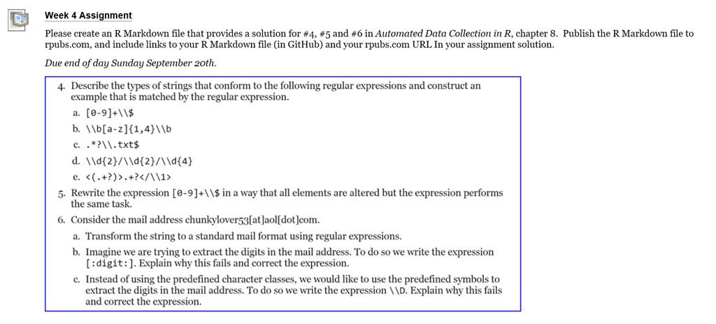

```r
## Install and load stringr package
install.packages("stringr", dependencies = TRUE, repos = "http://lib.stat.cmu.edu/R/CRAN/")
library(stringr)
## 4a. [0-9]+\\$
```

[0-9] means it will match any digit, the + means it will match the preceding any one or more times, the double backslash indicates it will be looking at the special character that follows as a literal character, so it will find any string that starts with any number of digits followed by a dollar sign

The type of string matched by this expression would be a price in the format 15$. It will list prices as whole numbers, if a price in the character string is done as a decimal, it will not extract the numbers before the decimal point, so it is important to know what the pricing format is, or it will extract an incorrect value for the price (the change value without the dollars).

An example of this would be as follows:

```r
## Create a vector with different price formats

price <- c("25$", "$60", "24.99$", "16#")
unlist(str_extract_all(price, "[0-9]+\\$"))
```

```
## [1] "25$" "99$"
```

```r
## 4b. \\b[a-z]{1,4}\\b
```

This should extract any word (double backslash was used to indicate to look for a word edge) made up of no more than 4 lowercase characters, like a to zzzz. A space will indicate the start of a new word, not seen as a character in a word.

```r
word_list <- c("Bob", "car", "blob", "seven", "baby", "ba b", "dadaa", "da da", "el piano")
unlist(str_extract_all(word_list, "\\b[a-z]{1,4}\\b"))
```

```
## [1] "car"  "blob" "baby" "ba"   "b"    "da"   "da"   "el"
```

```r
## 4c. .*?\\.txt$
```

.* means that a single character will be matched zero or more times, the ? means the preceding is optional and will be matched at most once. \. will match the . as a literal character, followed by txt at the end of the string (indicated by the $)

SO, this returns a single .txt file name, with any number or type of preceding character, and .txt has to be the end of the string

```r
f_names <- c("joe.txt", "*.txt", "*.doc", "a.txtf", "thomas.png", ".txt", ".abc.txt", ".txt.txt", "abc.txt.abc.txt")
unlist(str_extract_all(f_names, ".*?\\.txt$"))
```

```
## [1] "joe.txt"         "*.txt"           ".txt"            ".abc.txt"
## [5] ".txt.txt"        "abc.txt.abc.txt"
```

```r
## 4d. \\d{2}/\\d{2}/\\d{4}
```

This extracts 2 digits, then a slash, then 2 digits, then a slash then 4 digits - essentially the date if it is in month/day/year format. but it will return digits in this format that are not valid dates, and not return valid dates that have less than the correct number of digits

```r
vec_date <- c("Jan 31, 2015", "1/1/1", "15/76/3000", "09/17/2015", "2015/09/17" )
unlist(str_extract_all(vec_date, "\\d{2}/\\d{2}/\\d{4}"))
```

```
## [1] "15/76/3000" "09/17/2015"
```

```r
## 4e. <(.+?)>.+?</\\1>
```

This code will find HTML and XML elements

```r
x <- c("<abc> defabc <abc>", "<>", "<c>abdef</c>", "<head> <title>HTML Tutorial Example</title> </head>")
unlist(str_extract_all(x, "<(.+?)>.+?</\\1>"))
```

```
## [1] "<c>abdef</c>"
## [2] "<head> <title>HTML Tutorial Example</title> </head>"
```

```r
price <- c("25$", "$60", "24.99$", "16#")
unlist(str_extract_all(price, "\\d{1,}\\u0024"))
```

```
## [1] "25$" "99$"
```

```r
email_chunks <- unlist(str_extract_all("chunkylover53[at]aol[dot]com", "[[:alnum:]]*"))
email_chunks
```

```
##  [1] "chunkylover53" ""              "at"            ""
##  [5] "aol"           ""              "dot"           ""
##  [9] "com"           ""
```

```r
email_chunks[3] <- "@"
email_chunks[7] <- "."
email_addr <- str_c(email_chunks[1],email_chunks[3], email_chunks[5], email_chunks[7], email_chunks[9])
email_addr
```

```
## [1] "chunkylover53@aol.com"
```

```r
## The following expression fails because it gives only the first digit
str_extract("chunkylover53[at]aol[dot]com", "[:digit:]")
```

```
## [1] "5"
```

```r
## This statement gives you each digit individually, but you don't know that they occur together as 53 - you get the same answer for both of the following email addresses
str_extract_all("chunkylover53[at]aol[dot]com", "[:digit:]")
```

```
## [[1]]
## [1] "5" "3"
```

```r
str_extract_all("chunky5lover3[at]aol[dot]com", "[:digit:]")
```

```
## [[1]]
## [1] "5" "3"
```

```r
## The following code lets you see if the digits appear together, like 53
str_extract_all("chunkylover53[at]aol[dot]com", "[:digit:]+")
```

```
## [[1]]
## [1] "53"
```

```r
str_extract_all("chunky5lover3[at]aol[dot]com", "[:digit:]+")
```

```
## [[1]]
## [1] "5" "3"
```

```r
str_extract_all("chunkylover53[at]aol[dot]com", "\\D+")
```

```
## [[1]]
## [1] "chunkylover"     "[at]aol[dot]com"
```

```r
## Uppercase D extracts everything EXCEPT the digits.  we need to use the lowercase letter
str_extract_all("chunkylover53[at]aol[dot]com", "\\d+")
```

```
## [[1]]
## [1] "53"
```

```r
## Or if you want them individually
str_extract_all("chunkylover53[at]aol[dot]com", "\\d")
```

```
## [[1]]
## [1] "5" "3"
```